# Risk Factor Analysis

## Outcome Variable

**Outcome Variable:** ever_stunted

## Predictor Variables

**Intervention Variable:** hdlvry

**Adjustment Set:**

- arm
- sex
- W_mage
- meducyrs
- feducyrs
- hhwealth_quart
- single
- W_nrooms
- brthmon
- W_parity
- impsan
- delta_W_mage
- delta_meducyrs
- delta_feducyrs
- delta_hhwealth_quart
- delta_single
- delta_W_nrooms
- delta_brthmon
- delta_W_parity
- delta_impsan

## Stratifying Variables

The analysis was stratified on these variable(s):

- agecat
- studyid
- country

## Data Summary

| agecat | studyid | country | hdlvry | ever_stunted | n_cell | n |
| --- | --- | --- | --- | --- | --- | --- |
| 0-24 months (no birth st.) | CMC-V-BCS-2002 | INDIA | 0 | 0 | 27 | 293 |
| 0-24 months (no birth st.) | CMC-V-BCS-2002 | INDIA | 0 | 1 | 260 | 293 |
| 0-24 months (no birth st.) | CMC-V-BCS-2002 | INDIA | 1 | 0 | 1 | 293 |
| 0-24 months (no birth st.) | CMC-V-BCS-2002 | INDIA | 1 | 1 | 5 | 293 |
| 0-24 months (no birth st.) | COHORTS | INDIA | 0 | 0 | 2102 | 4479 |
| 0-24 months (no birth st.) | COHORTS | INDIA | 0 | 1 | 686 | 4479 |
| 0-24 months (no birth st.) | COHORTS | INDIA | 1 | 0 | 1017 | 4479 |
| 0-24 months (no birth st.) | COHORTS | INDIA | 1 | 1 | 674 | 4479 |
| 0-24 months (no birth st.) | EE | PAKISTAN | 0 | 0 | 29 | 212 |
| 0-24 months (no birth st.) | EE | PAKISTAN | 0 | 1 | 112 | 212 |
| 0-24 months (no birth st.) | EE | PAKISTAN | 1 | 0 | 12 | 212 |
| 0-24 months (no birth st.) | EE | PAKISTAN | 1 | 1 | 59 | 212 |
| 0-24 months (no birth st.) | GMS-Nepal | NEPAL | 0 | 0 | 66 | 535 |
| 0-24 months (no birth st.) | GMS-Nepal | NEPAL | 0 | 1 | 61 | 535 |
| 0-24 months (no birth st.) | GMS-Nepal | NEPAL | 1 | 0 | 168 | 535 |
| 0-24 months (no birth st.) | GMS-Nepal | NEPAL | 1 | 1 | 240 | 535 |
| 0-24 months (no birth st.) | IRC | INDIA | 0 | 0 | 145 | 360 |
| 0-24 months (no birth st.) | IRC | INDIA | 0 | 1 | 208 | 360 |
| 0-24 months (no birth st.) | IRC | INDIA | 1 | 0 | 2 | 360 |
| 0-24 months (no birth st.) | IRC | INDIA | 1 | 1 | 5 | 360 |
| 0-24 months (no birth st.) | JiVitA-3 | BANGLADESH | 0 | 0 | 25 | 259 |
| 0-24 months (no birth st.) | JiVitA-3 | BANGLADESH | 0 | 1 | 9 | 259 |
| 0-24 months (no birth st.) | JiVitA-3 | BANGLADESH | 1 | 0 | 137 | 259 |
| 0-24 months (no birth st.) | JiVitA-3 | BANGLADESH | 1 | 1 | 88 | 259 |
| 0-24 months (no birth st.) | JiVitA-4 | BANGLADESH | 0 | 0 | 541 | 3194 |
| 0-24 months (no birth st.) | JiVitA-4 | BANGLADESH | 0 | 1 | 339 | 3194 |
| 0-24 months (no birth st.) | JiVitA-4 | BANGLADESH | 1 | 0 | 1288 | 3194 |
| 0-24 months (no birth st.) | JiVitA-4 | BANGLADESH | 1 | 1 | 1026 | 3194 |
| 0-24 months (no birth st.) | NIH-Crypto | BANGLADESH | 0 | 0 | 320 | 653 |
| 0-24 months (no birth st.) | NIH-Crypto | BANGLADESH | 0 | 1 | 194 | 653 |

[output cut: 66 more lines]

The following strata were considered:

- agecat: 0-24 months (no birth st.), studyid: CMC-V-BCS-2002, country: INDIA
- agecat: 0-24 months (no birth st.), studyid: COHORTS, country: INDIA
- agecat: 0-24 months (no birth st.), studyid: EE, country: PAKISTAN
- agecat: 0-24 months (no birth st.), studyid: GMS-Nepal, country: NEPAL
- agecat: 0-24 months (no birth st.), studyid: IRC, country: INDIA
- agecat: 0-24 months (no birth st.), studyid: JiVitA-3, country: BANGLADESH
- agecat: 0-24 months (no birth st.), studyid: JiVitA-4, country: BANGLADESH
- agecat: 0-24 months (no birth st.), studyid: NIH-Crypto, country: BANGLADESH
- agecat: 0-24 months (no birth st.), studyid: PROVIDE, country: BANGLADESH
- agecat: 0-24 months (no birth st.), studyid: SAS-CompFeed, country: INDIA
- agecat: 0-24 months (no birth st.), studyid: SAS-FoodSuppl, country: INDIA
- agecat: 0-24 months (no birth st.), studyid: TanzaniaChild2, country: TANZANIA, UNITED REPUBLIC OF
- agecat: 0-6 months (no birth st.), studyid: CMC-V-BCS-2002, country: INDIA
- agecat: 0-6 months (no birth st.), studyid: COHORTS, country: INDIA
- agecat: 0-6 months (no birth st.), studyid: EE, country: PAKISTAN
- agecat: 0-6 months (no birth st.), studyid: GMS-Nepal, country: NEPAL
- agecat: 0-6 months (no birth st.), studyid: IRC, country: INDIA
- agecat: 0-6 months (no birth st.), studyid: JiVitA-3, country: BANGLADESH
- agecat: 0-6 months (no birth st.), studyid: JiVitA-4, country: BANGLADESH
- agecat: 0-6 months (no birth st.), studyid: NIH-Crypto, country: BANGLADESH
- agecat: 0-6 months (no birth st.), studyid: PROVIDE, country: BANGLADESH
- agecat: 0-6 months (no birth st.), studyid: SAS-CompFeed, country: INDIA
- agecat: 0-6 months (no birth st.), studyid: SAS-FoodSuppl, country: INDIA
- agecat: 0-6 months (no birth st.), studyid: TanzaniaChild2, country: TANZANIA, UNITED REPUBLIC OF

### Dropped Strata

Some strata were dropped due to rare outcomes:

- agecat: 0-24 months (no birth st.), studyid: CMC-V-BCS-2002, country: INDIA
- agecat: 0-24 months (no birth st.), studyid: IRC, country: INDIA
- agecat: 0-6 months (no birth st.), studyid: CMC-V-BCS-2002, country: INDIA
- agecat: 0-6 months (no birth st.), studyid: IRC, country: INDIA
- agecat: 0-6 months (no birth st.), studyid: JiVitA-3, country: BANGLADESH
- agecat: 0-6 months (no birth st.), studyid: SAS-FoodSuppl, country: INDIA

## Methods Detail

We're interested in the causal parameters $E[Y_a]$ for all values of $a \in \mathcal{A}$. These parameters represent the mean outcome if, possibly contrary to fact, we intervened to set all units to have $A=a$. Under the randomization and positivity assumptions, these are identified by the statistical parameters $\psi_a=E_W[E_{Y|A,W}(Y|A=a,W)]$. In addition, we're interested in the mean of $Y$, $E[Y]$ under no intervention (the observed mean). We will estimate these parameters by using SuperLearner to fit the relevant likelihood factors -- $E_{Y|A,W}(Y|A=a,W)$ and $p(A=a|W)$, and then updating our likelihood fit using a joint TMLE.

For unadjusted analyses ($W=\{\}$), initial likelihoods were estimated using Lrnr_glm to estimate the simple $E(Y|A)$ and Lrnr_mean to estimate $p(A)$. For adjusted analyses, a small library containing Lrnr_glmnet, Lrnr_xgboost, and Lrnr_mean was used.

Having estimated these parameters, we will then use the delta method to estimate relative risks and attributable risks relative to a prespecified baseline level of $A$.

# Results Detail

## Results Plots

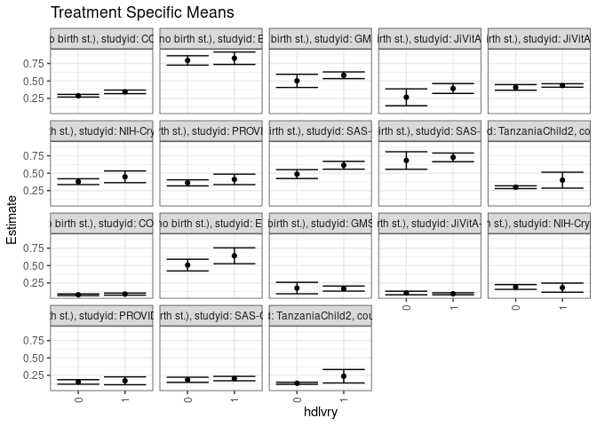

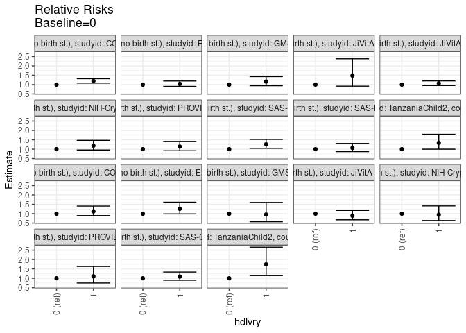

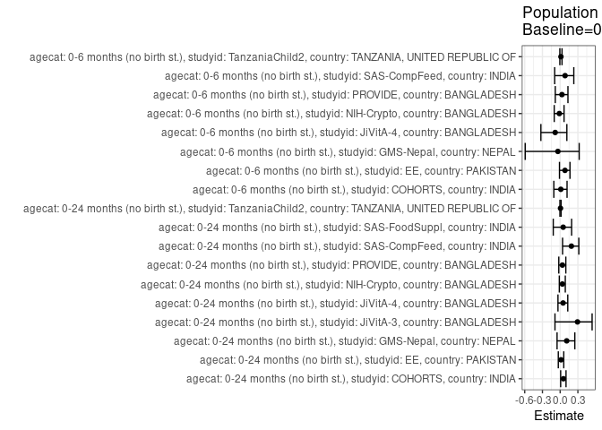

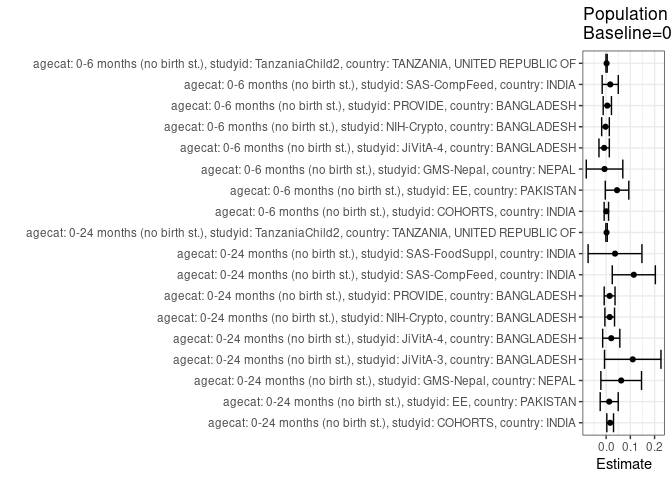

## Results Table

### Parameter: TSM

| agecat | studyid | country | intervention_level | baseline_level | estimate | ci_lower | ci_upper |
| --- | --- | --- | --- | --- | --- | --- | --- |
| 0-24 months (no birth st.) | COHORTS | INDIA | 0 | NA | 0.2869584 | 0.2678858 | 0.3060310 |
| 0-24 months (no birth st.) | COHORTS | INDIA | 1 | NA | 0.3424258 | 0.3167555 | 0.3680961 |
| 0-24 months (no birth st.) | EE | PAKISTAN | 0 | NA | 0.7939519 | 0.7268514 | 0.8610524 |
| 0-24 months (no birth st.) | EE | PAKISTAN | 1 | NA | 0.8256059 | 0.7365523 | 0.9146595 |
| 0-24 months (no birth st.) | GMS-Nepal | NEPAL | 0 | NA | 0.5004292 | 0.4055468 | 0.5953115 |
| 0-24 months (no birth st.) | GMS-Nepal | NEPAL | 1 | NA | 0.5807091 | 0.5325487 | 0.6288694 |
| 0-24 months (no birth st.) | JiVitA-3 | BANGLADESH | 0 | NA | 0.2647059 | 0.1432986 | 0.3861132 |
| 0-24 months (no birth st.) | JiVitA-3 | BANGLADESH | 1 | NA | 0.3911111 | 0.3201765 | 0.4620457 |
| 0-24 months (no birth st.) | JiVitA-4 | BANGLADESH | 0 | NA | 0.4062638 | 0.3659144 | 0.4466131 |
| 0-24 months (no birth st.) | JiVitA-4 | BANGLADESH | 1 | NA | 0.4341709 | 0.4095297 | 0.4588121 |
| 0-24 months (no birth st.) | NIH-Crypto | BANGLADESH | 0 | NA | 0.3788027 | 0.3370173 | 0.4205882 |
| 0-24 months (no birth st.) | NIH-Crypto | BANGLADESH | 1 | NA | 0.4487711 | 0.3645048 | 0.5330374 |
| 0-24 months (no birth st.) | PROVIDE | BANGLADESH | 0 | NA | 0.3616133 | 0.3181324 | 0.4050943 |
| 0-24 months (no birth st.) | PROVIDE | BANGLADESH | 1 | NA | 0.4112583 | 0.3360678 | 0.4864488 |
| 0-24 months (no birth st.) | SAS-CompFeed | INDIA | 0 | NA | 0.4877764 | 0.4242394 | 0.5513133 |
| 0-24 months (no birth st.) | SAS-CompFeed | INDIA | 1 | NA | 0.6144750 | 0.5582987 | 0.6706514 |
| 0-24 months (no birth st.) | SAS-FoodSuppl | INDIA | 0 | NA | 0.6831672 | 0.5572790 | 0.8090554 |
| 0-24 months (no birth st.) | SAS-FoodSuppl | INDIA | 1 | NA | 0.7279644 | 0.6656893 | 0.7902395 |
| 0-24 months (no birth st.) | TanzaniaChild2 | TANZANIA, UNITED REPUBLIC OF | 0 | NA | 0.2993609 | 0.2795816 | 0.3191401 |
| 0-24 months (no birth st.) | TanzaniaChild2 | TANZANIA, UNITED REPUBLIC OF | 1 | NA | 0.4007246 | 0.2864612 | 0.5149880 |
| 0-6 months (no birth st.) | COHORTS | INDIA | 0 | NA | 0.0803771 | 0.0682105 | 0.0925437 |
| 0-6 months (no birth st.) | COHORTS | INDIA | 1 | NA | 0.0904426 | 0.0754511 | 0.1054340 |
| 0-6 months (no birth st.) | EE | PAKISTAN | 0 | NA | 0.5068821 | 0.4233084 | 0.5904557 |
| 0-6 months (no birth st.) | EE | PAKISTAN | 1 | NA | 0.6405186 | 0.5263280 | 0.7547092 |
| 0-6 months (no birth st.) | GMS-Nepal | NEPAL | 0 | NA | 0.1767123 | 0.0944696 | 0.2589551 |
| 0-6 months (no birth st.) | GMS-Nepal | NEPAL | 1 | NA | 0.1692722 | 0.1327494 | 0.2057950 |
| 0-6 months (no birth st.) | JiVitA-4 | BANGLADESH | 0 | NA | 0.1061818 | 0.0807317 | 0.1316320 |
| 0-6 months (no birth st.) | JiVitA-4 | BANGLADESH | 1 | NA | 0.0947585 | 0.0805520 | 0.1089650 |
| 0-6 months (no birth st.) | NIH-Crypto | BANGLADESH | 0 | NA | 0.1925524 | 0.1583637 | 0.2267412 |
| 0-6 months (no birth st.) | NIH-Crypto | BANGLADESH | 1 | NA | 0.1828763 | 0.1176357 | 0.2481170 |
| 0-6 months (no birth st.) | PROVIDE | BANGLADESH | 0 | NA | 0.1547103 | 0.1220433 | 0.1873774 |
| 0-6 months (no birth st.) | PROVIDE | BANGLADESH | 1 | NA | 0.1709790 | 0.1145172 | 0.2274407 |
| 0-6 months (no birth st.) | SAS-CompFeed | INDIA | 0 | NA | 0.1860444 | 0.1491863 | 0.2229025 |
| 0-6 months (no birth st.) | SAS-CompFeed | INDIA | 1 | NA | 0.2030385 | 0.1718456 | 0.2342315 |
| 0-6 months (no birth st.) | TanzaniaChild2 | TANZANIA, UNITED REPUBLIC OF | 0 | NA | 0.1358202 | 0.1210246 | 0.1506157 |
| 0-6 months (no birth st.) | TanzaniaChild2 | TANZANIA, UNITED REPUBLIC OF | 1 | NA | 0.2368421 | 0.1403120 | 0.3333722 |

### Parameter: E(Y)

| agecat | studyid | country | intervention_level | baseline_level | estimate | ci_lower | ci_upper |
| --- | --- | --- | --- | --- | --- | --- | --- |
| 0-24 months (no birth st.) | COHORTS | INDIA | NA | NA | 0.3036392 | 0.2901712 | 0.3171072 |
| 0-24 months (no birth st.) | EE | PAKISTAN | NA | NA | 0.8066038 | 0.7533119 | 0.8598956 |
| 0-24 months (no birth st.) | GMS-Nepal | NEPAL | NA | NA | 0.5626168 | 0.5205427 | 0.6046909 |
| 0-24 months (no birth st.) | JiVitA-3 | BANGLADESH | NA | NA | 0.3745174 | 0.3090067 | 0.4400281 |
| 0-24 months (no birth st.) | JiVitA-4 | BANGLADESH | NA | NA | 0.4273638 | 0.4069167 | 0.4478110 |
| 0-24 months (no birth st.) | NIH-Crypto | BANGLADESH | NA | NA | 0.3935681 | 0.3560687 | 0.4310676 |
| 0-24 months (no birth st.) | PROVIDE | BANGLADESH | NA | NA | 0.3759874 | 0.3382238 | 0.4137509 |
| 0-24 months (no birth st.) | SAS-CompFeed | INDIA | NA | NA | 0.6020293 | 0.5512634 | 0.6527952 |
| 0-24 months (no birth st.) | SAS-FoodSuppl | INDIA | NA | NA | 0.7198444 | 0.6648337 | 0.7748550 |
| 0-24 months (no birth st.) | TanzaniaChild2 | TANZANIA, UNITED REPUBLIC OF | NA | NA | 0.3010803 | 0.2815901 | 0.3205706 |
| 0-6 months (no birth st.) | COHORTS | INDIA | NA | NA | 0.0812729 | 0.0731685 | 0.0893773 |
| 0-6 months (no birth st.) | EE | PAKISTAN | NA | NA | 0.5518868 | 0.4847863 | 0.6189873 |
| 0-6 months (no birth st.) | GMS-Nepal | NEPAL | NA | NA | 0.1700935 | 0.1382268 | 0.2019601 |
| 0-6 months (no birth st.) | JiVitA-4 | BANGLADESH | NA | NA | 0.0979284 | 0.0852731 | 0.1105838 |
| 0-6 months (no birth st.) | NIH-Crypto | BANGLADESH | NA | NA | 0.1898928 | 0.1597870 | 0.2199986 |
| 0-6 months (no birth st.) | PROVIDE | BANGLADESH | NA | NA | 0.1595577 | 0.1310079 | 0.1881074 |
| 0-6 months (no birth st.) | SAS-CompFeed | INDIA | NA | NA | 0.2029312 | 0.1748514 | 0.2310111 |
| 0-6 months (no birth st.) | TanzaniaChild2 | TANZANIA, UNITED REPUBLIC OF | NA | NA | 0.1376233 | 0.1229861 | 0.1522605 |

### Parameter: RR

| agecat | studyid | country | intervention_level | baseline_level | estimate | ci_lower | ci_upper |
| --- | --- | --- | --- | --- | --- | --- | --- |
| 0-24 months (no birth st.) | COHORTS | INDIA | 0 | 0 | 1.0000000 | 1.0000000 | 1.000000 |
| 0-24 months (no birth st.) | COHORTS | INDIA | 1 | 0 | 1.1932942 | 1.0806739 | 1.317651 |
| 0-24 months (no birth st.) | EE | PAKISTAN | 0 | 0 | 1.0000000 | 1.0000000 | 1.000000 |
| 0-24 months (no birth st.) | EE | PAKISTAN | 1 | 0 | 1.0398689 | 0.9064423 | 1.192936 |
| 0-24 months (no birth st.) | GMS-Nepal | NEPAL | 0 | 0 | 1.0000000 | 1.0000000 | 1.000000 |
| 0-24 months (no birth st.) | GMS-Nepal | NEPAL | 1 | 0 | 1.1604222 | 0.9431492 | 1.427748 |
| 0-24 months (no birth st.) | JiVitA-3 | BANGLADESH | 0 | 0 | 1.0000000 | 1.0000000 | 1.000000 |
| 0-24 months (no birth st.) | JiVitA-3 | BANGLADESH | 1 | 0 | 1.4775309 | 0.9188173 | 2.375986 |
| 0-24 months (no birth st.) | JiVitA-4 | BANGLADESH | 0 | 0 | 1.0000000 | 1.0000000 | 1.000000 |
| 0-24 months (no birth st.) | JiVitA-4 | BANGLADESH | 1 | 0 | 1.0686922 | 0.9521979 | 1.199439 |
| 0-24 months (no birth st.) | NIH-Crypto | BANGLADESH | 0 | 0 | 1.0000000 | 1.0000000 | 1.000000 |
| 0-24 months (no birth st.) | NIH-Crypto | BANGLADESH | 1 | 0 | 1.1847093 | 0.9542237 | 1.470867 |
| 0-24 months (no birth st.) | PROVIDE | BANGLADESH | 0 | 0 | 1.0000000 | 1.0000000 | 1.000000 |
| 0-24 months (no birth st.) | PROVIDE | BANGLADESH | 1 | 0 | 1.1372874 | 0.9157159 | 1.412472 |
| 0-24 months (no birth st.) | SAS-CompFeed | INDIA | 0 | 0 | 1.0000000 | 1.0000000 | 1.000000 |
| 0-24 months (no birth st.) | SAS-CompFeed | INDIA | 1 | 0 | 1.2597474 | 1.0435404 | 1.520749 |
| 0-24 months (no birth st.) | SAS-FoodSuppl | INDIA | 0 | 0 | 1.0000000 | 1.0000000 | 1.000000 |
| 0-24 months (no birth st.) | SAS-FoodSuppl | INDIA | 1 | 0 | 1.0655728 | 0.8692979 | 1.306164 |
| 0-24 months (no birth st.) | TanzaniaChild2 | TANZANIA, UNITED REPUBLIC OF | 0 | 0 | 1.0000000 | 1.0000000 | 1.000000 |
| 0-24 months (no birth st.) | TanzaniaChild2 | TANZANIA, UNITED REPUBLIC OF | 1 | 0 | 1.3386004 | 0.9988985 | 1.793827 |
| 0-6 months (no birth st.) | COHORTS | INDIA | 0 | 0 | 1.0000000 | 1.0000000 | 1.000000 |
| 0-6 months (no birth st.) | COHORTS | INDIA | 1 | 0 | 1.1252284 | 0.8995704 | 1.407493 |
| 0-6 months (no birth st.) | EE | PAKISTAN | 0 | 0 | 1.0000000 | 1.0000000 | 1.000000 |
| 0-6 months (no birth st.) | EE | PAKISTAN | 1 | 0 | 1.2636442 | 0.9900056 | 1.612917 |
| 0-6 months (no birth st.) | GMS-Nepal | NEPAL | 0 | 0 | 1.0000000 | 1.0000000 | 1.000000 |
| 0-6 months (no birth st.) | GMS-Nepal | NEPAL | 1 | 0 | 0.9578969 | 0.5732257 | 1.600707 |
| 0-6 months (no birth st.) | JiVitA-4 | BANGLADESH | 0 | 0 | 1.0000000 | 1.0000000 | 1.000000 |
| 0-6 months (no birth st.) | JiVitA-4 | BANGLADESH | 1 | 0 | 0.8924172 | 0.6768971 | 1.176558 |
| 0-6 months (no birth st.) | NIH-Crypto | BANGLADESH | 0 | 0 | 1.0000000 | 1.0000000 | 1.000000 |
| 0-6 months (no birth st.) | NIH-Crypto | BANGLADESH | 1 | 0 | 0.9497483 | 0.6375750 | 1.414770 |
| 0-6 months (no birth st.) | PROVIDE | BANGLADESH | 0 | 0 | 1.0000000 | 1.0000000 | 1.000000 |
| 0-6 months (no birth st.) | PROVIDE | BANGLADESH | 1 | 0 | 1.1051555 | 0.7492852 | 1.630045 |
| 0-6 months (no birth st.) | SAS-CompFeed | INDIA | 0 | 0 | 1.0000000 | 1.0000000 | 1.000000 |
| 0-6 months (no birth st.) | SAS-CompFeed | INDIA | 1 | 0 | 1.0913447 | 0.8933411 | 1.333235 |
| 0-6 months (no birth st.) | TanzaniaChild2 | TANZANIA, UNITED REPUBLIC OF | 0 | 0 | 1.0000000 | 1.0000000 | 1.000000 |
| 0-6 months (no birth st.) | TanzaniaChild2 | TANZANIA, UNITED REPUBLIC OF | 1 | 0 | 1.7437917 | 1.1436025 | 2.658974 |

### Parameter: PAR

| agecat | studyid | country | intervention_level | baseline_level | estimate | ci_lower | ci_upper |
| --- | --- | --- | --- | --- | --- | --- | --- |
| 0-24 months (no birth st.) | COHORTS | INDIA | 0 | NA | 0.0166808 | 0.0028745 | 0.0304871 |
| 0-24 months (no birth st.) | EE | PAKISTAN | 0 | NA | 0.0126518 | -0.0245405 | 0.0498442 |
| 0-24 months (no birth st.) | GMS-Nepal | NEPAL | 0 | NA | 0.0621877 | -0.0217353 | 0.1461106 |
| 0-24 months (no birth st.) | JiVitA-3 | BANGLADESH | 0 | NA | 0.1098115 | -0.0067521 | 0.2263750 |
| 0-24 months (no birth st.) | JiVitA-4 | BANGLADESH | 0 | NA | 0.0211000 | -0.0143103 | 0.0565103 |
| 0-24 months (no birth st.) | NIH-Crypto | BANGLADESH | 0 | NA | 0.0147654 | -0.0051350 | 0.0346658 |
| 0-24 months (no birth st.) | PROVIDE | BANGLADESH | 0 | NA | 0.0143740 | -0.0079946 | 0.0367426 |
| 0-24 months (no birth st.) | SAS-CompFeed | INDIA | 0 | NA | 0.1142529 | 0.0252582 | 0.2032477 |
| 0-24 months (no birth st.) | SAS-FoodSuppl | INDIA | 0 | NA | 0.0366771 | -0.0744891 | 0.1478434 |
| 0-24 months (no birth st.) | TanzaniaChild2 | TANZANIA, UNITED REPUBLIC OF | 0 | NA | 0.0017194 | -0.0011550 | 0.0045938 |
| 0-6 months (no birth st.) | COHORTS | INDIA | 0 | NA | 0.0008958 | -0.0081846 | 0.0099763 |
| 0-6 months (no birth st.) | EE | PAKISTAN | 0 | NA | 0.0450047 | -0.0035391 | 0.0935486 |
| 0-6 months (no birth st.) | GMS-Nepal | NEPAL | 0 | NA | -0.0066189 | -0.0820519 | 0.0688141 |
| 0-6 months (no birth st.) | JiVitA-4 | BANGLADESH | 0 | NA | -0.0082534 | -0.0296612 | 0.0131544 |
| 0-6 months (no birth st.) | NIH-Crypto | BANGLADESH | 0 | NA | -0.0026596 | -0.0184404 | 0.0131212 |
| 0-6 months (no birth st.) | PROVIDE | BANGLADESH | 0 | NA | 0.0048473 | -0.0122422 | 0.0219369 |
| 0-6 months (no birth st.) | SAS-CompFeed | INDIA | 0 | NA | 0.0168869 | -0.0163893 | 0.0501630 |
| 0-6 months (no birth st.) | TanzaniaChild2 | TANZANIA, UNITED REPUBLIC OF | 0 | NA | 0.0018031 | -0.0007036 | 0.0043098 |

### Parameter: PAF

| agecat | studyid | country | intervention_level | baseline_level | estimate | ci_lower | ci_upper |
| --- | --- | --- | --- | --- | --- | --- | --- |
| 0-24 months (no birth st.) | COHORTS | INDIA | 0 | NA | 0.0549362 | 0.0083433 | 0.0993399 |
| 0-24 months (no birth st.) | EE | PAKISTAN | 0 | NA | 0.0156853 | -0.0316101 | 0.0608125 |
| 0-24 months (no birth st.) | GMS-Nepal | NEPAL | 0 | NA | 0.1105329 | -0.0524019 | 0.2482419 |
| 0-24 months (no birth st.) | JiVitA-3 | BANGLADESH | 0 | NA | 0.2932080 | -0.0879598 | 0.5408333 |
| 0-24 months (no birth st.) | JiVitA-4 | BANGLADESH | 0 | NA | 0.0493725 | -0.0371617 | 0.1286869 |
| 0-24 months (no birth st.) | NIH-Crypto | BANGLADESH | 0 | NA | 0.0375168 | -0.0143903 | 0.0867677 |
| 0-24 months (no birth st.) | PROVIDE | BANGLADESH | 0 | NA | 0.0382300 | -0.0231867 | 0.0959602 |
| 0-24 months (no birth st.) | SAS-CompFeed | INDIA | 0 | NA | 0.1897797 | 0.0407038 | 0.3156890 |
| 0-24 months (no birth st.) | SAS-FoodSuppl | INDIA | 0 | NA | 0.0509515 | -0.1169857 | 0.1936396 |
| 0-24 months (no birth st.) | TanzaniaChild2 | TANZANIA, UNITED REPUBLIC OF | 0 | NA | 0.0057109 | -0.0038995 | 0.0152293 |
| 0-6 months (no birth st.) | COHORTS | INDIA | 0 | NA | 0.0110224 | -0.1072666 | 0.1166746 |
| 0-6 months (no birth st.) | EE | PAKISTAN | 0 | NA | 0.0815470 | -0.0115846 | 0.1661045 |
| 0-6 months (no birth st.) | GMS-Nepal | NEPAL | 0 | NA | -0.0389132 | -0.5920407 | 0.3220396 |
| 0-6 months (no birth st.) | JiVitA-4 | BANGLADESH | 0 | NA | -0.0842800 | -0.3260945 | 0.1134394 |
| 0-6 months (no birth st.) | NIH-Crypto | BANGLADESH | 0 | NA | -0.0140058 | -0.1006078 | 0.0657818 |
| 0-6 months (no birth st.) | PROVIDE | BANGLADESH | 0 | NA | 0.0303798 | -0.0827706 | 0.1317058 |
| 0-6 months (no birth st.) | SAS-CompFeed | INDIA | 0 | NA | 0.0832147 | -0.0928412 | 0.2309081 |
| 0-6 months (no birth st.) | TanzaniaChild2 | TANZANIA, UNITED REPUBLIC OF | 0 | NA | 0.0131018 | -0.0053045 | 0.0311711 |